# Statics: solving of systems of linear equations

Use Juypter Notebook for symbolic calculus.

## E3.a - Task

[figure not shown]

- **given:**
  - $F, a, q_0, \alpha$
- **wanted:**
  - static external (support reactions) and internal force equilibria
  - plot of the components internal force equilibrium
- **procedure:**
  - get function for distributed load $q(x)$
  - get components of the resulting moment/torque using $\vec{M} = \vec{r} \times \vec{F}$
  - set up system of linear equations to obtain the support reactions
  - solve the system of linear equations using **sympy.solve**
  - set up system of linear equations to obtain the internal force equilibrium
  - plot the internal force components along the beam axis ($x$-axis)
- **pseudo-code**:

Note

Do this task inside a jupyter notebook!

[output not shown]

- **Solution:**

# E3.A - Task

```python
reset -f
```

```python
import sympy as sp
import numpy as np
import matplotlib.pyplot as plt

from IPython.display import Math, Latex
```

## Define symbolic variables

```python
a, F, q0, alpha, x = sp.symbols('a, F, q0, alpha,x', real = 'True')
Bx, By, Cy, Gx1, Gx2, Gy1, Gy2, Dy = sp. symbols('Bx, By, Cy, Gx1, Gx2, Gy1, Gy2, Dy', real = 'True')
```

## Derive q(x)

```python
def q(xL,xH):
    return sp.integrate(q0, (x, xL, xH))
```

```python
eq1 = sp.Eq(0 , Bx + Gx1 + sp.cos(alpha) * F)
eq2 = sp.Eq(0 , By + Cy + Gy1 - F*sp.sin(alpha) - q(0,a))
eq3 = sp.Eq(0, -F*sp.sin(alpha)*a + Cy*2*a + Gy1*3*a - q(0,a)*5/2*a)
eq4 = sp.Eq(0, Gx1 + Gx2)
eq5 = sp.Eq(0, Gy1 + Gy2)
eq6 = sp.Eq(0, Gx1)
eq7 = sp.Eq(0, Gy2 + Dy - q(a,2*a))
eq8 = sp.Eq(0, -Gy2*a + q(a,2*a)*1/2*a)
```

```python
sol = sp.solve([eq1, eq2, eq3, eq4, eq5, eq6, eq7, eq8],[Bx, By, Cy, Gx1, Gx2, Gy1, Gy2, Dy])
sol
```

```
{Bx: -F*cos(alpha),
 Gx1: 0,
 Gx2: 0,
 By: F*sin(alpha)/2 - a*q0/2,
 Cy: F*sin(alpha)/2 + 2*a*q0,
 Gy1: -a*q0/2,
 Gy2: a*q0/2,
 Dy: a*q0/2}
```

```python
Bx, Gx1, Gx2, By, Cy, Gy1, Gy2, Dy = sol.values()
```

# Internal force reactions

## Define symbolic functions

```python
N1 = sp.Function('N1')(x)
N2 = sp.Function('N2')(x)
N3 = sp.Function('N3')(x)

Q1 = sp.Function('Q1')(x)
Q2 = sp.Function('Q2')(x)
Q3 = sp.Function('Q3')(x)

Mbz1 = sp.Function('Mbz1')(x)
Mbz2 = sp.Function('Mbz2')(x)
Mbz3 = sp.Function('Mbz3')(x)
```

## Set up equations

```python
eq11 = sp.Eq(0, N1 + Bx)
eq12 = sp.Eq(0, Q1 + By)
eq13 = sp.Eq(0, Mbz1 - By*x)

eq21 = sp.Eq(0, N2 + Bx + F*sp.cos(alpha))
eq22 = sp.Eq(0, Q2 + By - F*sp.sin(alpha))
eq23 = sp.Eq(0, Mbz2 - By*x + F*sp.sin(alpha)*(x-a))

eq31 = sp.Eq(0, -N3)
eq32 = sp.Eq(0, -Q3 + Dy - q(x, 4*a))
eq33 = sp.Eq(0, -Mbz3 + Dy*(4*a - x) - q(x, 4*a)*(4*a - x)/2)
```

```python
sp.simplify(eq32)
```

$\displaystyle \frac{7 a q_{0}}{2} - q_{0} x + \operatorname{Q_{3}}{\left(x \right)} = 0$

# solve equations

```python
sol = sp.solve([eq11, eq12, eq13, eq21, eq22, eq23, eq31, eq32, eq33],[N1, N2, N3, Q1, Q2, Q3, Mbz1, Mbz2, Mbz3])
sol
```

```
{N1(x): F*cos(alpha),
 Q1(x): -F*sin(alpha)/2 + a*q0/2,
 Mbz1(x): F*x*sin(alpha)/2 - a*q0*x/2,
 N2(x): 0,
 Q2(x): F*sin(alpha)/2 + a*q0/2,
 Mbz2(x): F*a*sin(alpha) - F*x*sin(alpha)/2 - a*q0*x/2,
 N3(x): 0,
 Q3(x): -7*a*q0/2 + q0*x,
 Mbz3(x): -6*a**2*q0 + 7*a*q0*x/2 - q0*x**2/2}
```

```python
N1, Q1, Mbz1, N2, Q2, Mbz2, N3, Q3, Mbz3 = sol.values()
```

```python
N = sp.Piecewise([N1, x <= a], [N2,(x > a) & (x <= 2*a)], [N3,(x > 2*a) & (x <= 4*a)])
Q = sp.Piecewise([Q1, x <= a], [Q2,(x > a) & (x <= 2*a)], [Q3,(x > 2*a) & (x <= 4*a)])
Mbz = sp.Piecewise([Mbz1, x <= a], [Mbz2,(x > a) & (x <= 2*a)], [Mbz3,(x > 2*a) & (x <= 4*a)])
```

```python
Mbz
```

$\displaystyle \begin{cases} \frac{F x \sin{\left(\alpha \right)}}{2} - \frac{a q_{0} x}{2} & \text{for}\: a \geq x \\F a \sin{\left(\alpha \right)} - \frac{F x \sin{\left(\alpha \right)}}{2} - \frac{a q_{0} x}{2} & \text{for}\: x \leq 2 a \\- 6 a^{2} q_{0} + \frac{7 a q_{0} x}{2} - \frac{q_{0} x^{2}}{2} & \text{for}\: x \leq 4 a \end{cases}$

```python
N = N.subs([(F, 1), (alpha, sp.pi/4), (a,10), (q0, 0.3)])
Q = Q.subs([(F, 1), (alpha, sp.pi/4), (a,10), (q0, 0.3)])
Mbz = Mbz.subs([(F, 1), (alpha, sp.pi/4), (a,10), (q0, 0.3)])
```

```python
N_fun = sp.lambdify(x, N, 'numpy')
Q_fun = sp.lambdify(x, Q, 'numpy')
Mbz_fun = sp.lambdify(x, Mbz, 'numpy')

s = np.arange(0,40,1)
```

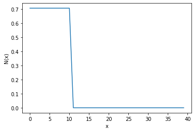

```python
plt.plot(s, N_fun(s))
plt.xlabel('x')
plt.ylabel('N(x)')
```

[figure not shown]

```python
plt.plot(s, Q_fun(s))
plt.xlabel('x')
plt.ylabel('Q(x)')
```

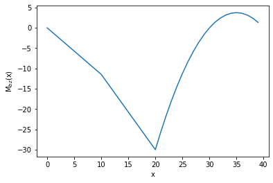

```python
plt.plot(s, Mbz_fun(s))
plt.xlabel('x')
plt.ylabel('M$_{bz}$(x)')
```

## E3.b - Task

[figure not shown]

- **given:**
  - $L, q_0$
- **wanted:**
  - static external (support reactions) and internal force equilibria
  - plot of the components internal force equilibrium
- **procedure:**
  - get function for distributed load $q(x)$
  - get components of the resulting moment/torque using $\vec{M} = \vec{r} \times \vec{F}$
  - set up system of linear equations to obtain the support reactions
  - solve the system of linear equations using **sympy.solve**
  - set up system of linear equations to obtain the internal force equilibrium
  - plot the internal force components of $M_{bz1}, M_{bz2}, M_{bz3}$ along the beam axis ($x$-axis)
- **pseudo-code**:

Note

Do this task inside a jupyter notebook!

[output not shown]